# ODD General Analysis

Kerim Acar

25/10/2018

# Introduction & Manipulation of Dataset

First, I introduced the dataset then I did some manipulation to rows that contain wrong information. I also created a joint ‘Date’ variable from year and month.

```r
rds_data <- readRDS("C:/Users/kerim.acar/Desktop/BDA/BDA503/car_data_aggregate.rds")
rds_data <- rds_data %>%
  filter(!(startsWith(brand_name, "ODD") | startsWith(brand_name, "TOPLAM")))

rds_data$Date <- as.Date(as.yearmon(paste(rds_data$year, rds_data$month), "%Y %m"), frac = 1)
rds_data <- rds_data %>%
              arrange(Date)
```

# Total Sales by Brands

I wanted to see the best and the worst sellers in the time period between January 2016 and September 2018.

```r
rds_total_total <- rds_data %>%
  group_by(brand_name) %>%
  summarise(total_total = sum(total_total)) %>%
  arrange(desc(total_total))
```

# Top, Average and Bottom Sellers Selection

I wanted to analyze the sale performances of brands, so I included 3 top sellers(RENAULT, FIAT, FORD), 2 average sellers (AUDI, BMW) and 1 bottom seller (VOLVO).

```r
selected_data<- subset(rds_data,brand_name == 'RENAULT' |
                    brand_name =='FIAT' | brand_name =='FORD' |
                     brand_name =='AUDI' | brand_name == 'VOLVO' |
                     brand_name == 'BMW')
selected_data <- selected_data[,c(1,10,13)]
head(selected_data)
```

```
## # A tibble: 6 x 3
##   brand_name total_total Date
##   <chr>            <dbl> <date>
## 1 AUDI               911 2016-01-31
## 2 BMW                496 2016-01-31
## 3 FIAT              3843 2016-01-31
## 4 FORD              3770 2016-01-31
## 5 RENAULT           4519 2016-01-31
## 6 VOLVO              187 2016-01-31
```

# Sales Trends Among Selected Brands

I made a scatter plot of sales by time among selected brands.

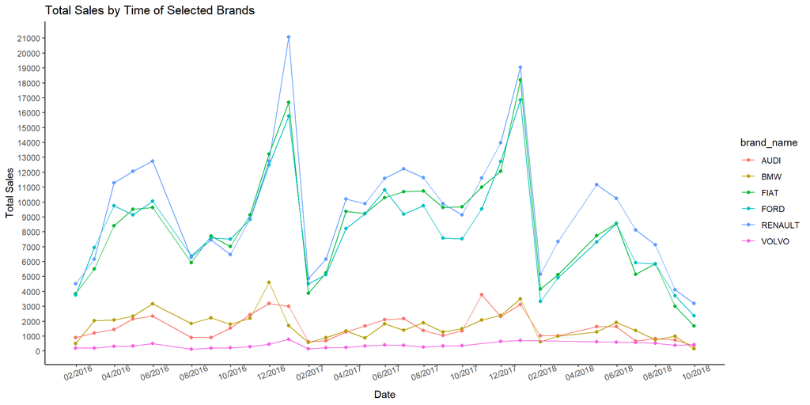

```r
ggplot(data=selected_data, aes(x=Date,y=total_total,color=brand_name))+
  scale_x_date(labels = date_format("%m/%Y"),breaks = date_breaks(width = "2 months"))+
  geom_point() +
  scale_y_continuous(breaks = seq(0,21000, 1000)) +
  theme_classic() + geom_line()+ theme(axis.text.x = element_text(angle=20)) +
  ylab("Total Sales") + ggtitle("Total Sales by Time of Selected Brands")
```

As we can see from the graph, top sellers’ sales follow the same trend which increases sharply at the end of the year and decreases at the same scale after the beginning of the next year.

# Correlation Between Brands

I changed the format of dataset which takes selected brands as columns, dates as rows and filled with total sales.

```r
selected_data<- selected_data[,c("Date","brand_name","total_total")]
new<-selected_data %>%
  spread(brand_name,total_total)
head(new)
```

```
## # A tibble: 6 x 7
##   Date        AUDI   BMW  FIAT  FORD RENAULT VOLVO
##   <date>     <dbl> <dbl> <dbl> <dbl>   <dbl> <dbl>
## 1 2016-01-31   911   496  3843  3770    4519   187
## 2 2016-02-29  1200  2042  5502  6940    6162   194
## 3 2016-03-31  1455  2080  8400  9758   11293   311
## 4 2016-04-30  2148  2332  9521  9151   12075   335
## 5 2016-05-31  2352  3174  9636 10051   12741   512
## 6 2016-07-31   905  1856  5929  6370    6274   130
```

Then, I created a correlation matrix for selected brands. As shown in previous graph, top sellers(FIAT, FORD, RENAULT) are highly correlated with each other.

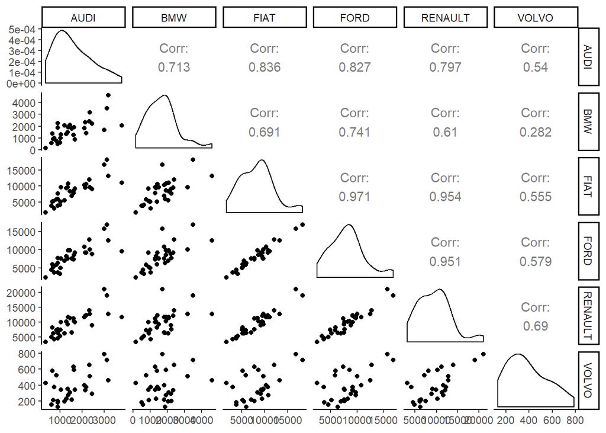

```r
ggpairs(new[,-1])+ theme_classic()
```